# RI Daily Policies Prophet Model

## About Prophet

Prophet is the industry standard code library for forecasting business time series data. It was developed by engineers as Facebook and is based on a non-linear modular regression model. Prophet parameters are easy to interpret and adjust thus simplifying the process of creating accurate domain-specific forecasts. The Prophet model formulation is:

$y(t) = g(t) + s(t) + h(t) + \epsilon_{t}$

where:

$g(t)$ is the overall time series trend function

$s(t)$ represents periodic changes (daily, weekly, monthly, and/or yearly seasonality)

$h(t)$ represents the effects of holidays or other irregular changes

$\epsilon_{t}$ is the error term

A detailed explanation of Prophet can be found here: https://peerj.com/preprints/3190.pdf

## RI Data

The input data for the Prophet Model comes from the `RI_POLICY_FACT` table which will be housed in APPFDW (pending QA/QC). The model requires two variables: the date that the RI policies were issued `ISSUED_DATE` and the number of new policies `NEW_POLICIES`. A snapshot of the data is below:

```r
head(ns)
```

```
## # A tibble: 6 × 2
##   ISSUED_DATE NEW_POLICIES
##   <chr>              <int>
## 1 2022-02-22            19
## 2 2022-02-21           617
## 3 2022-02-20           211
## 4 2022-02-19           261
## 5 2022-02-18           695
## 6 2022-02-17           654
```

## Exploratory Data Analysis

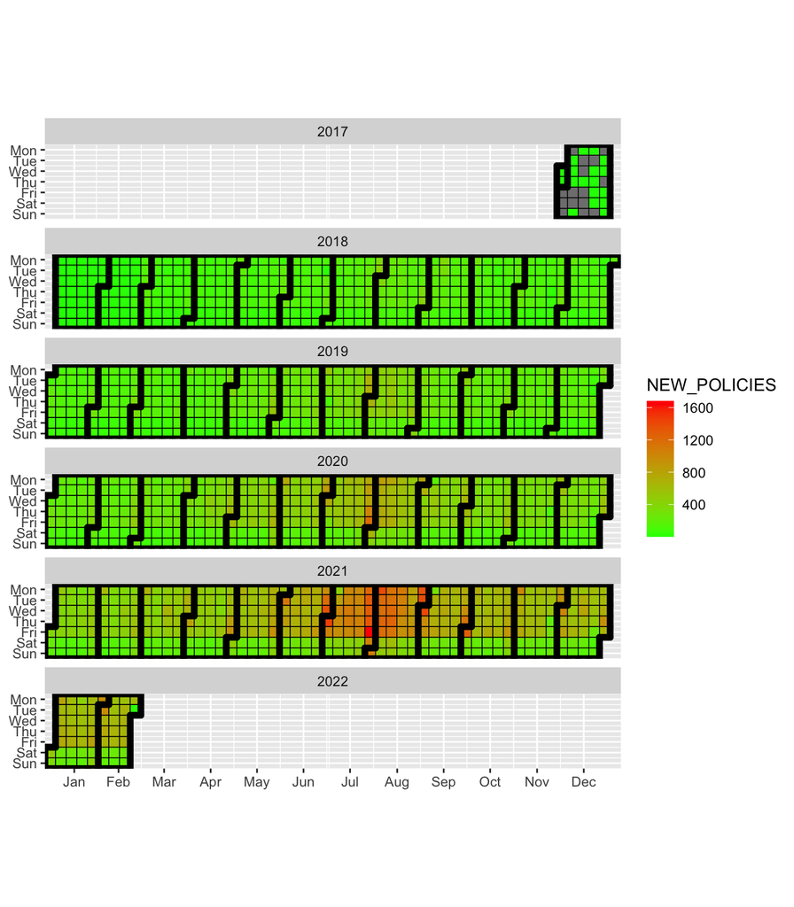

## Basic Model Formulation

The daily cumulative number of new policies sold was chosen as the forecast metric. This allows us to more easily visualize growth and identify when key milestones are approaching (e.g 500,000 RI Policies Sold). The R code for creating a basic model is shown below:

```r
#create basic model
m = prophet(c)

#forecast 365 days into the future
future = make_future_dataframe(m, periods = 365)
forecast <- predict(m, future)
```

This plot shows the model output. Black dots represent the actual cumulative total of new policies sold each day, and the dark blue line shows the daily cumulative totals estimated by the model. The light blue region shows the range of model uncertainty.

[interactive chart not shown]

## Next Steps

- Perform model cross-validation
- Incorporate additional regressors to account for RI seasonalities
- Refine model parameters to improve fit
- Complete 2022 forecasting of new policies sold
- Develop additional models for long term forecasting of policy renewals and cancellations